# Ch08 Simple Regression Tree for Advertising

Bruce Hartman

University of St. Francis

2025-09-29 Revised 2026-10-25T13:15:57

Abstract

We apply decision trees to the Advertising data. Decision trees are in Chapter 8 of the text.

# Introduction

Here is a basic discussion of regression trees. A good source for this topic is from the University of Cincinnati, which has a good business analytics program. Another good one is from Datacamp. The basic reference on tree modeling is Breiman et al., 1984.

Decision Trees work by recursively partitioning the data one variable at a time. Predictions are obtained by finding out which leaf of the tree an observation comes out in; the mean value of the target in that leaf is assigned as the prediction.

The interpretation of a decision tree is easy, though perhaps not as easy as a linear regression. But it has a lot of intuition behind it. Of course data scientists have carried the concept to extremes, designing more complicated variations. And those are correspondingly less explainable.

Our text gives a good discussion of decision trees and their variations. However, this notebook does not follow the book. It’s even simpler.

# Packages

As usual, we have some standard packages. Code for regression trees can be found in the packages `rpart, rpart.plot` which you must load.

```r
library(ISLR2)
library(rpart) # for decision trees
library(rpart.plot) # plotting decision trees
library(mbadtools, quietly=TRUE) # some extra ggplot functions
```

# Data

Load the advertising data. It’s in a csv file from early in the course. You can use Import Dataset.

```r
Advertising <- read_csv("Advertising.csv")
```

# Data Description

Give the data a short df name.

```r
data = Advertising
data
```

| ...1 | TV | Radio | Newspaper | Sales |
| --- | --- | --- | --- | --- |
| 1 | 230.1 | 37.8 | 69.2 | 22.1 |
| 2 | 44.5 | 39.3 | 45.1 | 10.4 |
| 3 | 17.2 | 45.9 | 69.3 | 9.3 |
| 4 | 151.5 | 41.3 | 58.5 | 18.5 |
| 5 | 180.8 | 10.8 | 58.4 | 12.9 |
| 6 | 8.7 | 48.9 | 75.0 | 7.2 |
| 7 | 57.5 | 32.8 | 23.5 | 11.8 |
| 8 | 120.2 | 19.6 | 11.6 | 13.2 |
| 9 | 8.6 | 2.1 | 1.0 | 4.8 |
| 10 | 199.8 | 2.6 | 21.2 | 10.6 |

[output cut: 190 more lines]

The first column has a strange name. It numbers the Ad Campaigns studied. Sales is considered to be the target variable. the others are the drivers, the amount invested in the types of advertising for the campaign.

# Data Wrangling

We change the name of the first column.

```r
data = data %>% rename(Campaign=1)
data %>% glimpse
```

```
Rows: 200
Columns: 5
$ Campaign  <dbl> 1, 2, 3, 4, 5, 6, 7, 8, 9, 10, 11, 12, 13, 14, 15, 16, 17, 1…
$ TV        <dbl> 230.1, 44.5, 17.2, 151.5, 180.8, 8.7, 57.5, 120.2, 8.6, 199.…
$ Radio     <dbl> 37.8, 39.3, 45.9, 41.3, 10.8, 48.9, 32.8, 19.6, 2.1, 2.6, 5.…
$ Newspaper <dbl> 69.2, 45.1, 69.3, 58.5, 58.4, 75.0, 23.5, 11.6, 1.0, 21.2, 2…
$ Sales     <dbl> 22.1, 10.4, 9.3, 18.5, 12.9, 7.2, 11.8, 13.2, 4.8, 10.6, 8.6…
```

# Research Problem

We will build a regression tree to model the prediction of Sales from the other variables. This is a supervised method. We will compare the result with a linear model.

# Method

We will use a simple regression tree. To build the tree we will use the `rpart` function from the package of the same name.

# Set a seed

Since it does some randomization we set a seed so the notebook will reproduce.

```r
set.seed(1)
```

# Calculate Regression Tree

We want a regression tree so we set ‘method’ to “anova”.

```r
tree.rpart <- rpart(
  formula = Sales~TV+Radio+Newspaper,
  data    = data,
  method  = "anova" #this is for regression tree
)
```

# Summarize result

The summary tells you what happened at each step of the construction, and much else.

```r
summary(tree.rpart)
```

```
Call:
rpart(formula = Sales ~ TV + Radio + Newspaper, data = data,
    method = "anova")
  n= 200

          CP nsplit  rel error    xerror       xstd
1 0.47231685      0 1.00000000 1.0119410 0.08965773
2 0.27180247      1 0.52768315 0.5871078 0.04992348
3 0.06431633      2 0.25588068 0.2960494 0.02931395
4 0.03479185      3 0.19156435 0.2286310 0.02147405
5 0.03211535      4 0.15677249 0.2065570 0.01900822
6 0.02932104      5 0.12465714 0.2003285 0.02007031
7 0.01828406      6 0.09533610 0.1294217 0.01342383
8 0.01000000      7 0.07705205 0.1058935 0.01098258

Variable importance
       TV     Radio Newspaper
       54        34        12

Node number 1: 200 observations,    complexity param=0.4723168
  mean=14.0225, MSE=27.08574
  left son=2 (83 obs) right son=3 (117 obs)
  Primary splits:
      TV        < 122.05 to the left,  improve=0.47231680, (0 missing)
      Radio     < 26.75  to the left,  improve=0.27575420, (0 missing)
      Newspaper < 50.9   to the left,  improve=0.09879543, (0 missing)
  Surrogate splits:
      Radio     < 1.75   to the left,  agree=0.62, adj=0.084, (0 split)
      Newspaper < 1.35   to the left,  agree=0.59, adj=0.012, (0 split)

Node number 2: 83 observations,    complexity param=0.06431633
  mean=9.775904, MSE=7.978937
  left son=4 (26 obs) right son=5 (57 obs)
  Primary splits:
      TV        < 30.05  to the left,  improve=0.52610070, (0 missing)
      Radio     < 40.45  to the left,  improve=0.15173080, (0 missing)
      Newspaper < 31.65  to the left,  improve=0.08102853, (0 missing)
  Surrogate splits:
      Newspaper < 65.75  to the right, agree=0.711, adj=0.077, (0 split)

```

[output cut: 62 more lines]

```
  mean=21.94872, MSE=5.855319
  left son=30 (17 obs) right son=31 (22 obs)
  Primary splits:
      Radio     < 35.3   to the left,  improve=0.69556070, (0 missing)
      TV        < 264.8  to the left,  improve=0.26250890, (0 missing)
      Newspaper < 39.15  to the left,  improve=0.08590855, (0 missing)
  Surrogate splits:
      Newspaper < 17.2   to the left,  agree=0.667, adj=0.235, (0 split)
      TV        < 291.3  to the right, agree=0.590, adj=0.059, (0 split)

Node number 30: 17 observations
  mean=19.65294, MSE=0.8907266

Node number 31: 22 observations
  mean=23.72273, MSE=2.471756
```

# Visualize the tree

There are various types of plots. The default is type=2.

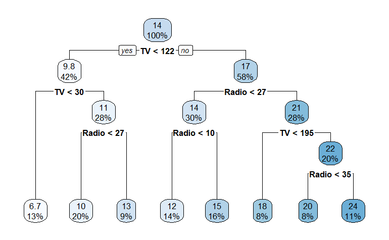

```r
rpart.plot(tree.rpart) #default type is 2
```

More types of plot.

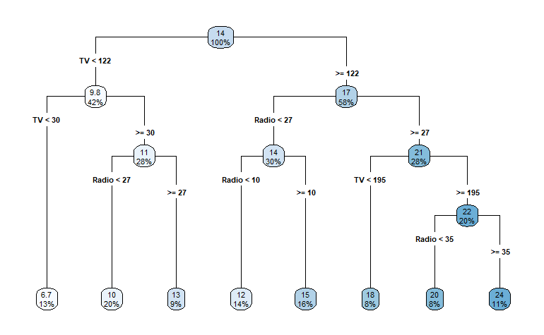

```r
rpart.plot(tree.rpart, type=4)
```

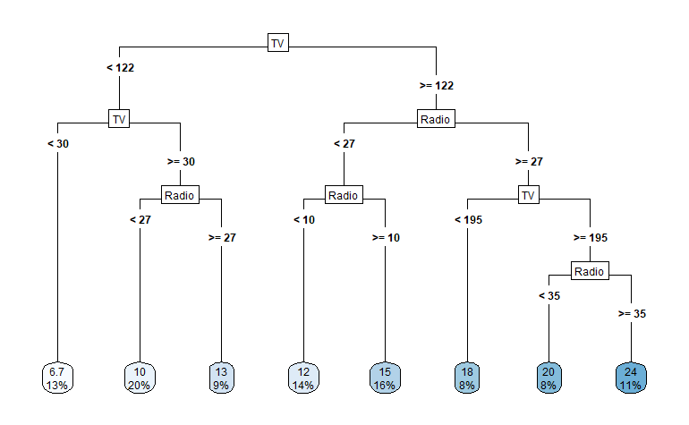

```r
rpart.plot(tree.rpart, type=5)
```

The numbers at the bottom are the mean values of Sales in the various tree classes. The percentages are the percentages of cases that fall there.

# Predictions

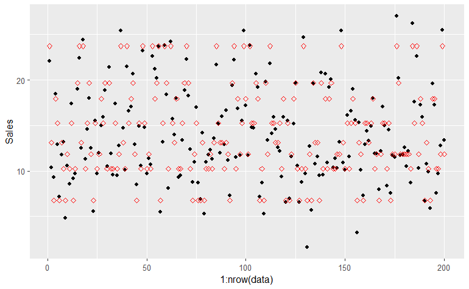

```r
tree.prediction=predict(tree.rpart,data)
ggplot(data, aes(1:nrow(data), Sales)) +
  geom_point() +
  geom_point(aes(1:nrow(data), tree.prediction), color="red", shape=5)
```

# Calculate mean average percentage error (MAPE)

```r
tree.prediction.error = sum(abs(tree.prediction - data$Sales))/sum(data$Sales)
tree.prediction.error
```

```
[1] 0.08224568
```

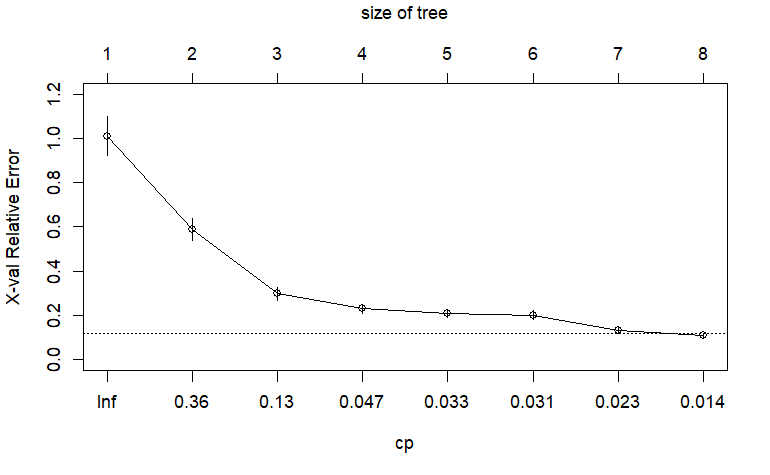

```r
plotcp(tree.rpart)
```

# Linear Regression

Now we do a linear regression on all drivers for comparison and report the MAPE of the predictions on the dataset.

```r
model1 = lm(Sales ~ TV + Radio + Newspaper, data)
model1.prediction = predict(model1, data )
model1.prediction.error = sum(abs(model1.prediction - data$Sales))/sum(data$Sales)
model1.prediction.error
```

```
[1] 0.08928588
```

# Conclusion

Tree prediction error is a bit less than ordinary regression prediction error. You’ll get a different answer if you rerun the tree with a different seed.

```r
data.frame(MAPE.linear = model1.prediction.error, MAPE.tree = tree.prediction.error)
```

| MAPE.linear | MAPE.tree |
| --- | --- |
| 0.08928588 | 0.08224568 |

# References

1. @bradleyboehmke (2018) UC Business Analytics R Programming Guide. *UC Business Analytics* https://uc-r.github.io/regression_trees
2. Arunn Thevapalan and James Le (2023) Decision Trees in Machine Learning Using R. *Datacamp* Updated May 2023 https://www.datacamp.com/tutorial/decision-trees-R
3. Breiman L., Friedman J. H., Olshen R. A., and Stone, C. J. (1984) Classification and Regression Trees. Wadsworth.
4. ISLR (2013) Chapter 8: Tree-Based Methods. page 303ff.